# MA4128 Assignment

Jack Curtin, ID: 16181484

# Technical Report

### Exploratory Analysis

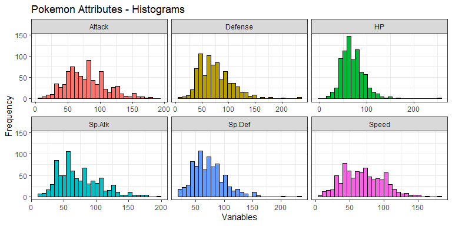

The dataset we are considering consists of 800 Pokemon, each of which have a unique combination of battling statistics along with other characteristics. Our main objective is to identify what Pokemon exhibit similar battling characteristics. It should be noted that *Type* and *Generation* are the only categorical variables in this dataset. To begin analysing our data, we will look at a summary statistic for each of our non-categorical variables to determine if our data contains any abnormalities and if the data needs to be standardised.

| var | min | q25 | median | q75 | max | mean | sd |
| --- | --- | --- | --- | --- | --- | --- | --- |
| Attack | 5 | 55.00 | 75 | 100 | 190 | 79.00125 | 32.45737 |
| Defense | 5 | 50.00 | 70 | 90 | 230 | 73.84250 | 31.18350 |
| HP | 1 | 50.00 | 65 | 80 | 255 | 69.25875 | 25.53467 |
| Sp.Atk | 10 | 49.75 | 65 | 95 | 194 | 72.82000 | 32.72229 |
| Sp.Def | 20 | 50.00 | 70 | 90 | 230 | 71.90250 | 27.82892 |
| Speed | 5 | 45.00 | 65 | 90 | 180 | 68.27750 | 29.06047 |

From this table there doesn’t seem to be any abnormalities in our data and the variances don’t vary massively although we will still standardise our data to ensure each variable is of equal weight when we look into creating clusters. We can also look at the histograms above for our data and use the `ggpairs()` function to create pairs plots for our numeric variables, which has the following output:

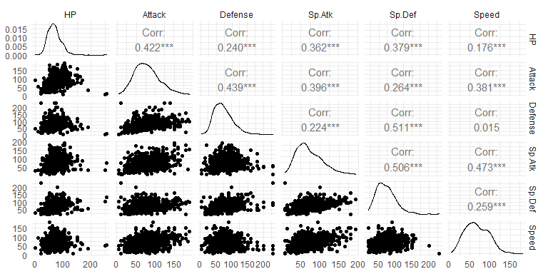

This can be interpreted to mean that whilst there are no strong associations in our data, we do have moderate associations between $\it Sp.Def$ and $\it Defense$ and $\it Sp.Def$ and $\it Sp.Atk$. There are also appears to be a few outliers in the data, although none seem to be of major significance.

### Standardise the data

To begin formally analysing our data we must first standardised the data. We achieve this by dividing each of the variables by their standard deviation, which results in each standard deviation being equal to one.

| var | min | median | max | mean | sd |
| --- | --- | --- | --- | --- | --- |
| Attack | 0.1540482 | 2.310724 | 5.853833 | 2.434001 | 1 |
| Defense | 0.1603412 | 2.244777 | 7.375695 | 2.367999 | 1 |
| HP | 0.0391624 | 2.545559 | 9.986423 | 2.712342 | 1 |
| Sp.Atk | 0.3056020 | 1.986413 | 5.928680 | 2.225394 | 1 |
| Sp.Def | 0.7186769 | 2.515369 | 8.264785 | 2.583733 | 1 |
| Speed | 0.1720550 | 2.236715 | 6.193980 | 2.349497 | 1 |

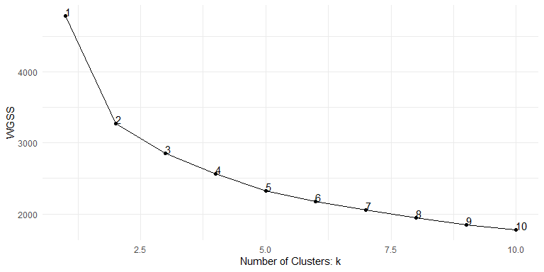

We can determine the *elbow point* from our plot to be between 2 and 4, in this case we will choose 4 as the plot gradually tapers after 4. Below we see the number of Pokemon in each cluster and also the centers of each cluster.

| Cluster | # | HP | Attack | Defense | Sp.Atk | Sp.Def | Speed |
| --- | --- | --- | --- | --- | --- | --- | --- |
| 1 | 203 | 2.827413 | 2.576627 | 2.096599 | 2.378276 | 2.564048 | 3.133096 |
| 2 | 280 | 1.956724 | 1.656019 | 1.667778 | 1.460996 | 1.768587 | 1.691424 |
| 3 | 195 | 3.190835 | 2.652000 | 3.301220 | 2.263022 | 3.198481 | 1.805254 |
| 4 | 122 | 3.490272 | 3.633771 | 2.935033 | 3.665221 | 3.504728 | 3.425869 |

### Visualising the cluster solution

We can visualize the clusters using principal components where we take $\it Hp$ to be PC1 and $\it Attack$ to be PC2 as shown below. We can see that our clusters are reasonably distinguishable in this plot.

[figure not shown]

We can also further analyse our results if we export a data frame to excel which has an additional column defining each cluster and another column defining the average of our standardised numeric variables (to objectively determine the best Pokemon). We find a summary of our results from that table to be as follows which shows the amount of each Generation and the amount of each Type in our Clusters.

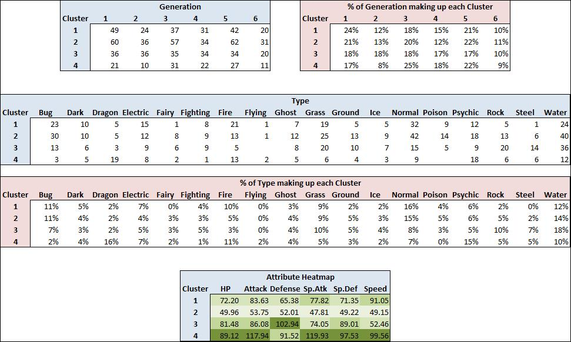

We find the worst Pokemon to objectively be the following:

| Name | Type | HP | Attack | Defense | Sp.Atk | Sp.Def | Speed | Generation | Cluster |
| --- | --- | --- | --- | --- | --- | --- | --- | --- | --- |
| Sunkern | Grass | 30 | 30 | 30 | 30 | 30 | 30 | 2 | 2 |
| Azurill | Normal | 50 | 20 | 40 | 20 | 40 | 20 | 3 | 2 |
| Kricketot | Bug | 37 | 25 | 41 | 25 | 41 | 25 | 4 | 2 |
| Wurmple | Bug | 45 | 45 | 35 | 20 | 30 | 20 | 3 | 2 |
| Weedle | Bug | 40 | 35 | 30 | 20 | 20 | 50 | 1 | 2 |
| Ralts | Psychic | 28 | 25 | 25 | 45 | 35 | 40 | 3 | 2 |

We find the best Pokemon to objectively be the following:

|  | Name | Type | HP | Attack | Defense | Sp.Atk | Sp.Def | Speed | Generation | Cluster |
| --- | --- | --- | --- | --- | --- | --- | --- | --- | --- | --- |
| 795 | Arceus | Normal | 120 | 120 | 120 | 120 | 120 | 120 | 4 | 4 |
| 796 | GroudonPrimal Groudon | Ground | 100 | 180 | 160 | 150 | 90 | 90 | 3 | 4 |
| 797 | KyogrePrimal Kyogre | Water | 100 | 150 | 90 | 180 | 160 | 90 | 3 | 4 |
| 798 | RayquazaMega Rayquaza | Dragon | 105 | 180 | 100 | 180 | 100 | 115 | 3 | 4 |
| 799 | MewtwoMega Mewtwo X | Psychic | 106 | 190 | 100 | 154 | 100 | 130 | 1 | 4 |
| 800 | MewtwoMega Mewtwo Y | Psychic | 106 | 150 | 70 | 194 | 120 | 140 | 1 | 4 |

### Conclusion

Upon further inspection using summaries from Excel to analyse each cluster we come to the conclusion that the Pokemon which have the best battling characteristics are *Legendary Pokemon* and *Final Evolution Pokemon*. From our analysis Cluster 4 contains the best overall Pokemon as it contains the most Legendary and Final Evolution Pokemon. Cluster 2 contains the worst overall Pokemon and it is therefore best to avoid choosing any pokemon from this cluster. Clusters 1 and 3 have similar values with 3 having the best overall $\it Defense$ values and 1 having the second best overall $\it Speed$ values. From our analysis it seems that no Generation stands out as having better overall Pokemon than the other Generations. The best Type appears to be Dragon, Psychic and Fire and the worst Type seems to be Bug and arguably Normal. Water seems to be the most diverse Type as it makes up roughly 14% of each cluster. We thus conclude that the best Pokemon are Legendary and Final Evolution Pokemon, the majority of which are in Cluster 4, and that it is best to obtain Dragon and Fire Type and avoid Bug Type if possible.

# Non-Technical Report

[figure not shown]

We could see that some clusters had better variable scores than others, which implied that Pokemon in one cluster had better scores than those in another. We could see that the average scores for each variable were higher in Cluster 4 than the other clusters and that Cluster 2 contained the worst overall scores for each variable, which suggests that it is best to avoid Pokemon contained in Cluster 2 and to seek out any Pokemon from Cluster 4. We also looked at a summary for the Generation and Type contained in each cluster and we came to the conclusion that Generation has no major bearing on how good a Pokemon’s battling attributes will be. We did however conclude that the Bug Type appeared to be the worst and that Dragon and Psychic appeared to be the best Types in terms of battling attributes. In reality the defining factor as to why the Cluster 4 scores were far better than the others was because this cluster contained what are known as *Legendary Pokemon* and *Final Evolution Pokemon*, which are Pokemon that are rare and as such difficult to obtain.